# Customer RFM Segmentation with R

Wei Xie

10/23/2018

# Introduction

In this document, I will reproduce a recent [blog article on customer segmentation](https://towardsdatascience.com/find-your-best-customers-with-customer-segmentation-in-python-61d602f9eee6) in R.

# Analysis

## Libraries and Data File

We can download the data file from the [UCI Archive](http://archive.ics.uci.edu/ml/datasets/online+retail).

```r
df <- read_excel("Online Retail.xlsx")
```

## Exploratory

### Data Summary

Let’s first take a glimpse of the data file.

```r
glimpse(df)
```

```
## Observations: 541,909
## Variables: 8
## $ InvoiceNo   <chr> "536365", "536365", "536365", "536365", "536365", ...
## $ StockCode   <chr> "85123A", "71053", "84406B", "84029G", "84029E", "...
## $ Description <chr> "WHITE HANGING HEART T-LIGHT HOLDER", "WHITE METAL...
## $ Quantity    <dbl> 6, 6, 8, 6, 6, 2, 6, 6, 6, 32, 6, 6, 8, 6, 6, 3, 2...
## $ InvoiceDate <dttm> 2010-12-01 08:26:00, 2010-12-01 08:26:00, 2010-12...
## $ UnitPrice   <dbl> 2.55, 3.39, 2.75, 3.39, 3.39, 7.65, 4.25, 1.85, 1....
## $ CustomerID  <dbl> 17850, 17850, 17850, 17850, 17850, 17850, 17850, 1...
## $ Country     <chr> "United Kingdom", "United Kingdom", "United Kingdo...
```

### Missing Data

Let’s check if any of the columns have NA’s and the percentage if yes.

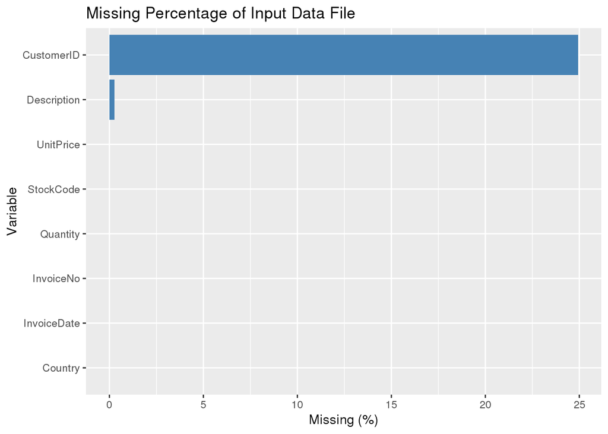

```r
df %>% summarize_all(funs(sum(ifelse(is.na(.),1,0)/n()*100))) %>%
  gather() %>%
  ggplot(aes(x=reorder(key,value), y=value)) +
  geom_bar(stat="identity",fill="steelblue") +
  labs(x="Variable", y="Missing (%)") +
  coord_flip() +
  ggtitle("Missing Percentage of Input Data File")
```

About 25% of customerID is missing while a minor fraction of the Description is missing.

### Transacton Time Period

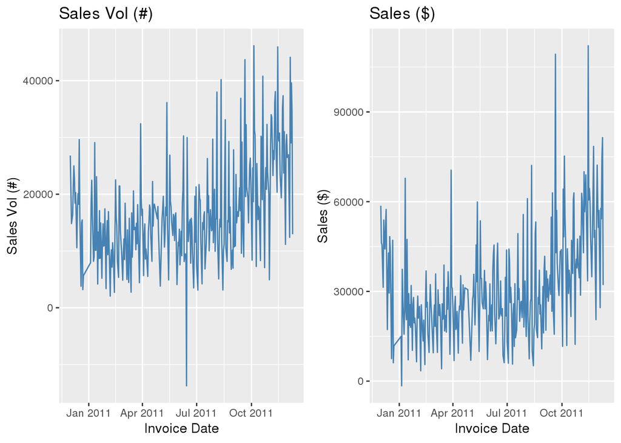

```r
df %>%
  mutate(InvoiceDate=make_date(year(InvoiceDate),month(InvoiceDate), day(InvoiceDate))) %>%
  group_by(InvoiceDate) %>%
  summarize(n = n(),
            sales_vol = sum(Quantity),
            sales= sum(UnitPrice * Quantity)) %>%
  ungroup() %>%
  ggplot(aes(x=InvoiceDate, y=sales_vol)) +
  geom_line(color="steelblue") +
  labs(x="Invoice Date", y="Sales Vol (#)") +
  ggtitle("Sales Vol (#)") -> p1

df %>%
  mutate(InvoiceDate=make_date(year(InvoiceDate),month(InvoiceDate), day(InvoiceDate))) %>%
  group_by(InvoiceDate) %>%
  summarize(n = n(),
            sales_vol = sum(Quantity),
            sales= sum(UnitPrice * Quantity)) %>%
  ungroup() %>%
  ggplot(aes(x=InvoiceDate, y=sales)) +
  geom_line(color="steelblue") +
  labs(x="Invoice Date", y="Sales ($)") +
  ggtitle("Sales ($)") -> p2

grid.arrange(p1,p2,ncol=2)
```

We can see the sales Vol (#) gas a negative value in June 2011. Meanwhile, we see both the sales vol (#) and sales ($) are quite volatile.

### Stock Category

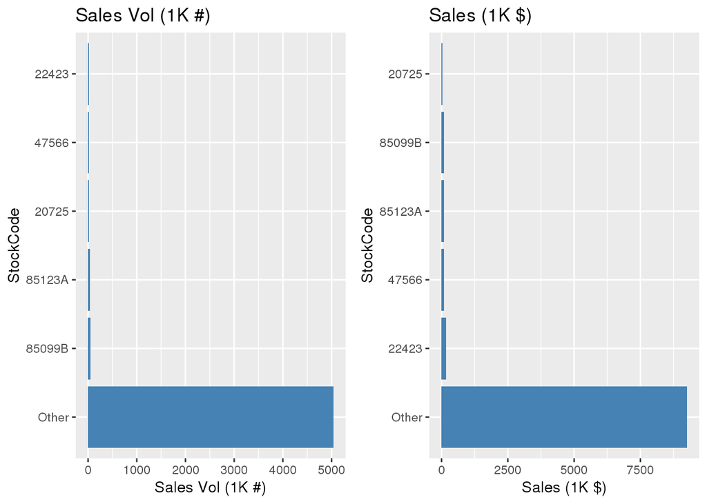

```r
div <- 1000

df %>%
  mutate(StockCode = as.factor(StockCode) %>% fct_lump(prop=0.003)) %>%
  group_by(StockCode) %>%
  summarize(sales_vol = sum(Quantity),
            sales = sum(UnitPrice * Quantity)) %>%
  ungroup() %>%
  ggplot(aes(x=reorder(StockCode, -sales_vol), y=sales_vol/div)) +
  geom_bar(stat="identity", fill="steelblue") +
  labs(x="StockCode", y="Sales Vol (1K #)") +
  coord_flip() +
  scale_y_continuous() +
  ggtitle("Sales Vol (1K #)") -> p1

df %>%
  mutate(StockCode = as.factor(StockCode) %>% fct_lump(prop=0.003)) %>%
  group_by(StockCode) %>%
  summarize(sales_vol = sum(Quantity),
            sales = sum(UnitPrice * Quantity)) %>%
  ungroup() %>%
  ggplot(aes(x=reorder(StockCode, -sales), y=sales/div)) +
  geom_bar(stat="identity", fill="steelblue") +
  labs(x="StockCode", y="Sales (1K $)") +
  coord_flip() +
  scale_y_continuous() +
  ggtitle("Sales (1K $)") -> p2

grid.arrange(p1,p2,ncol=2)
```

We can see the sales consists of many inventories, each of which only accounts for a very small fraction of the total.

### Customer summary

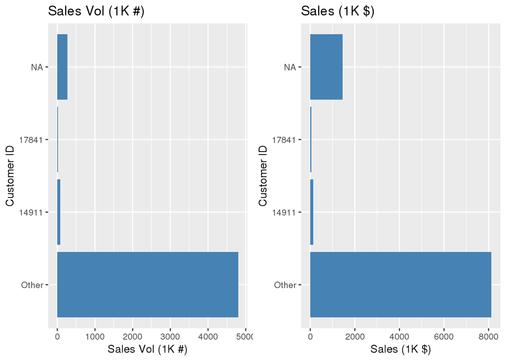

```r
div <- 1000

df %>%
  mutate(CustomerID=as.factor(CustomerID) %>% fct_lump(prop=0.01)) %>%
  group_by(CustomerID) %>%
  summarize(sales_vol=sum(Quantity),
            sales=sum(UnitPrice * Quantity)) %>%
  ungroup() %>%
  ggplot(aes(x=reorder(CustomerID,-sales_vol),  y=sales_vol/div)) +
  geom_bar(stat="identity",fill="steelblue") +
  labs(x="Customer ID", y="Sales Vol (1K #)") +
  coord_flip() +
  ggtitle("Sales Vol (1K #)") -> p1

df %>%
  mutate(CustomerID=as.factor(CustomerID) %>% fct_lump(prop=0.01)) %>%
  group_by(CustomerID) %>%
  summarize(sales_vol=sum(Quantity),
            sales=sum(UnitPrice * Quantity)) %>%
  ungroup() %>%
  ggplot(aes(x=reorder(CustomerID,-sales),  y=sales/div)) +
  geom_bar(stat="identity",fill="steelblue") +
  labs(x="Customer ID", y="Sales (1K $)") +
  coord_flip() +
  ggtitle("Sales (1K $)") -> p2

grid.arrange(p1,p2,ncol=2)
```

Again, we see no dominant customers and a significant portion of customers with missing identification.

### Country Summary

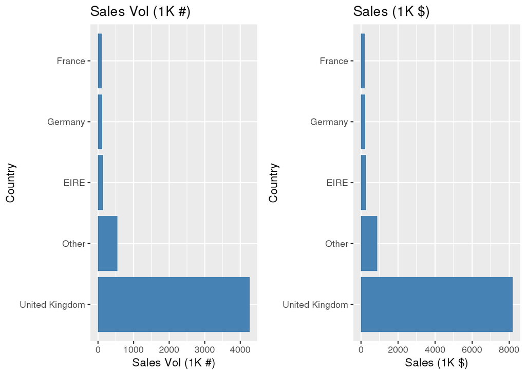

```r
div <- 1000

df %>%
  mutate(Country=as.factor(Country) %>% fct_lump(prop=0.01)) %>%
  group_by(Country) %>%
  summarize(sales_vol=sum(Quantity),
            sales=sum(UnitPrice * Quantity)) %>%
  ungroup() %>%
  ggplot(aes(x=reorder(Country,-sales_vol),  y=sales_vol/div)) +
  geom_bar(stat="identity",fill="steelblue") +
  labs(x="Country", y="Sales Vol (1K #)") +
  coord_flip() +
  ggtitle("Sales Vol (1K #)") -> p1

df %>%
  mutate(Country=as.factor(Country) %>% fct_lump(prop=0.01)) %>%
  group_by(Country) %>%
  summarize(sales_vol=sum(Quantity),
            sales=sum(UnitPrice * Quantity)) %>%
  ungroup() %>%
  ggplot(aes(x=reorder(Country,-sales),  y=sales/div)) +
  geom_bar(stat="identity",fill="steelblue") +
  labs(x="Country", y="Sales (1K $)") +
  coord_flip() +
  ggtitle("Sales (1K $)") -> p2

grid.arrange(p1,p2,ncol=2)
```

We can see most of the sales occur in UK.

## Reports

### Data filtering

Since we are producing a customer value segmentation, we will

1. remove all records with missing CustomerID.
2. remove negative quantity.

```r
df %>% filter(! is.na(CustomerID)) %>%
  filter(Quantity >= 0) -> df_new

glimpse(df_new)
```

```
## Observations: 397,924
## Variables: 8
## $ InvoiceNo   <chr> "536365", "536365", "536365", "536365", "536365", ...
## $ StockCode   <chr> "85123A", "71053", "84406B", "84029G", "84029E", "...
## $ Description <chr> "WHITE HANGING HEART T-LIGHT HOLDER", "WHITE METAL...
## $ Quantity    <dbl> 6, 6, 8, 6, 6, 2, 6, 6, 6, 32, 6, 6, 8, 6, 6, 3, 2...
## $ InvoiceDate <dttm> 2010-12-01 08:26:00, 2010-12-01 08:26:00, 2010-12...
## $ UnitPrice   <dbl> 2.55, 3.39, 2.75, 3.39, 3.39, 7.65, 4.25, 1.85, 1....
## $ CustomerID  <dbl> 17850, 17850, 17850, 17850, 17850, 17850, 17850, 1...
## $ Country     <chr> "United Kingdom", "United Kingdom", "United Kingdo...
```

The new data set has about 400K records.

### RFM Table

To calculate recency, we need to convert datetime of InvoiceDate to date.

```r
df_new %>% mutate(InvoiceDate = make_date(year(InvoiceDate), month(InvoiceDate), day(InvoiceDate))) -> df_new

df_new %>% summarize(min_InvoiceDate=min(InvoiceDate),
                     max_InvoiceDate=max(InvoiceDate))
```

```
## # A tibble: 1 x 2
##   min_InvoiceDate max_InvoiceDate
##   <date>          <date>
## 1 2010-12-01      2011-12-09
```

We see the transactions are between 12/1/2010 and 12/9/2011. Therefore, we can use 12/10/2011 as the reference date to calculate recency.

```r
ref_date <- ymd("2011-12-10")

df_new %>% mutate(days_lastbuy=as.numeric(ref_date - InvoiceDate, units="days")) %>%
  group_by(CustomerID, Country) %>%
  summarize(recency=max(days_lastbuy),
            frequency=n(),
            monetary_value=sum(Quantity * UnitPrice)) %>%
  ungroup() %>%
  arrange(desc(monetary_value), recency, desc(frequency)) -> df_rfm

df_rfm
```

```
## # A tibble: 4,347 x 5
##    CustomerID Country        recency frequency monetary_value
##         <dbl> <chr>            <dbl>     <int>          <dbl>
##  1      14646 Netherlands        355      2080        280206.
##  2      18102 United Kingdom     368       431        259657.
##  3      17450 United Kingdom     368       337        194551.
##  4      16446 United Kingdom     206         3        168472.
##  5      14911 EIRE               374      5677        143825.
##  6      12415 Australia          338       716        124915.
##  7      14156 EIRE               372      1400        117380.
##  8      17511 United Kingdom     374       963         91062.
##  9      16029 United Kingdom     374       242         81025.
## 10      12346 United Kingdom     326         1         77184.
## # ... with 4,337 more rows
```

### Quartile RFM

```r
df_rfm %>%
  mutate(r_quartile=ntile(desc(recency),4),
         f_quartile=ntile(desc(frequency),4),
         m_quartile=ntile(desc(monetary_value),4),
         rfm_score=paste(r_quartile,
                         f_quartile,
                         m_quartile, sep="")) -> df_rfm_qtl

df_rfm_qtl
```

```
## # A tibble: 4,347 x 9
##    CustomerID Country recency frequency monetary_value r_quartile
##         <dbl> <chr>     <dbl>     <int>          <dbl>      <int>
##  1      14646 Nether…     355      2080        280206.          1
##  2      18102 United…     368       431        259657.          1
##  3      17450 United…     368       337        194551.          1
##  4      16446 United…     206         3        168472.          3
##  5      14911 EIRE        374      5677        143825.          1
##  6      12415 Austra…     338       716        124915.          1
##  7      14156 EIRE        372      1400        117380.          1
##  8      17511 United…     374       963         91062.          1
##  9      16029 United…     374       242         81025.          1
## 10      12346 United…     326         1         77184.          2
## # ... with 4,337 more rows, and 3 more variables: f_quartile <int>,
## #   m_quartile <int>, rfm_score <chr>
```

We can find our top 10 customer as

```r
df_rfm_qtl %>%
  filter(rfm_score=="111") %>%
  arrange(desc(monetary_value)) %>%
  top_n(10)
```

```
## # A tibble: 428 x 9
##    CustomerID Country recency frequency monetary_value r_quartile
##         <dbl> <chr>     <dbl>     <int>          <dbl>      <int>
##  1      14646 Nether…     355      2080        280206.          1
##  2      18102 United…     368       431        259657.          1
##  3      17450 United…     368       337        194551.          1
##  4      14911 EIRE        374      5677        143825.          1
##  5      12415 Austra…     338       716        124915.          1
##  6      14156 EIRE        372      1400        117380.          1
##  7      17511 United…     374       963         91062.          1
##  8      16029 United…     374       242         81025.          1
##  9      16684 United…     359       277         66654.          1
## 10      13694 United…     374       568         65040.          1
## # ... with 418 more rows, and 3 more variables: f_quartile <int>,
## #   m_quartile <int>, rfm_score <chr>
```

Our top customer 14646 does not exist in the original analysis. Let’s find out what has caused it.

```r
df %>% filter(CustomerID == "14646")
```

```
## # A tibble: 2,085 x 8
##    InvoiceNo StockCode Description Quantity InvoiceDate         UnitPrice
##    <chr>     <chr>     <chr>          <dbl> <dttm>                  <dbl>
##  1 539491    21981     PACK OF 12…       12 2010-12-20 10:09:00     0.290
##  2 539491    21986     PACK OF 12…       12 2010-12-20 10:09:00     0.290
##  3 539491    22720     SET OF 3 C…        2 2010-12-20 10:09:00     4.95
##  4 539491    21931     JUMBO STOR…        1 2010-12-20 10:09:00     1.95
##  5 539491    22613     PACK OF 20…        2 2010-12-20 10:09:00     0.85
##  6 539491    20751     FUNKY WASH…        1 2010-12-20 10:09:00     2.1
##  7 539491    21246     RED RETROS…        2 2010-12-20 10:09:00     4.95
##  8 539491    22960     JAM MAKING…        1 2010-12-20 10:09:00     4.25
##  9 539491    22355     CHARLOTTE …        2 2010-12-20 10:09:00     0.85
## 10 539491    21123     SET/10 IVO…        2 2010-12-20 10:09:00     1.25
## # ... with 2,075 more rows, and 2 more variables: CustomerID <dbl>,
## #   Country <chr>
```

It turns out that this customer is in Netherland and the original analysis only included customers in UK.

# Conclusions

In conclusions, we have successfully conduct RFM analysis and it confirms the conclusions of the previous analysis. In addition, we also show that although UK customers contribute to the most sales, some non-UK customers actually are top contributors as well. Therefore, we may want to include them in the future analysis.